# ggplot Tips and Alternate Plotting Libraries

Travis Blimkie

October 2nd, 2019

Today we’re going to look at a few ways of imporving on default ggplot2 graphics, as well as explore some other packages for plotting data. Specifically, we’re going to look at the `cowplot` package for tweaking our ggplot2 figures, then produce interactive graphics via the `plotly` package. Finally we’ll use the built-in `mtcars` data set to test out these different plotting methods.

Let’s start by loading the libraries we’ll need.

```r
# install.packages(c("cowplot", "plotly"))
library(cowplot)
library(plotly)
library(tidyverse)

data("mtcars")
mtcars <- mtcars %>% rownames_to_column("car")
```

Let’s start by making a standard plot using `ggplot2` to get our baseline.

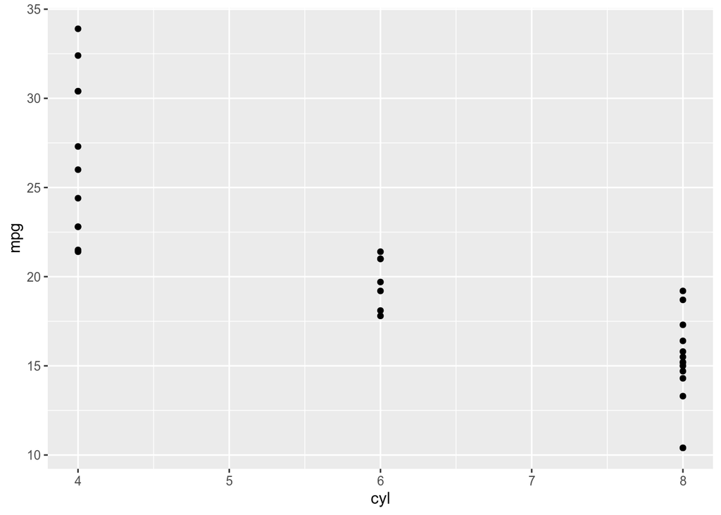

```r
ggplot(mtcars, aes(cyl, mpg)) +
  geom_point()
```

Let’s see how we can tweak this plot using the available methods. We’ll be making use of two functions here: `labs()` to create labels, and `theme()` to customize the appearance of our plot. Let’s change the axis labels, add a title, and change the overall theme with `theme_bw()`.

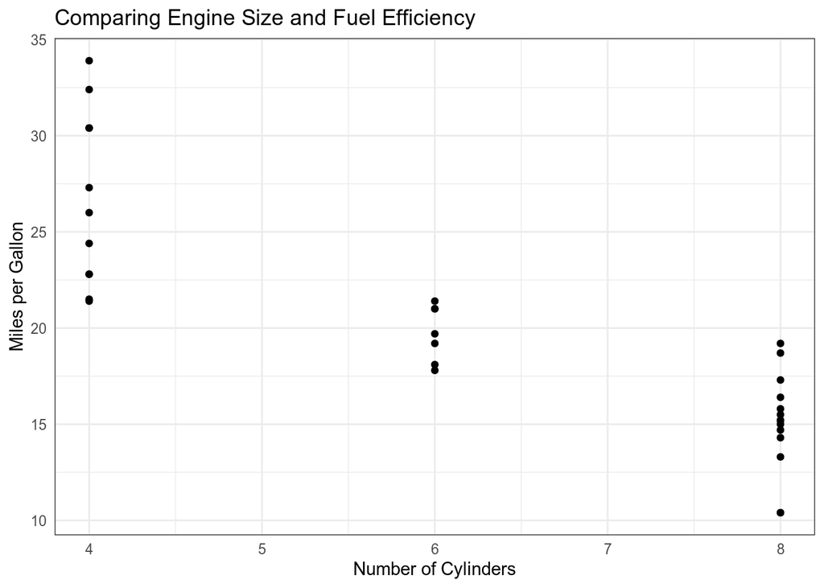

```r
ggplot(mtcars, aes(cyl, mpg)) +
  geom_point() +
  labs(x = "Number of Cylinders",
       y = "Miles per Gallon",
       title = "Comparing Engine Size and Fuel Efficiency") +
  theme_bw() +
  theme(axis.ticks = element_blank())
```

The `theme_bw()` function is acting as a “preset”, changing multiple arguments of the regular `theme()` function at once. There are some additional versions of `theme_bw()`, such as `theme_classic()`, and `theme_grey()`. For `theme()` itself, there are a whole range of arguments that can be used to alter the appearance of the plot. Any argument you want to specify must be in the format of `element_x()` (like the `element_blank()` we used earlier). Let’s build on this example by increasing the font size, as the default is often too small.

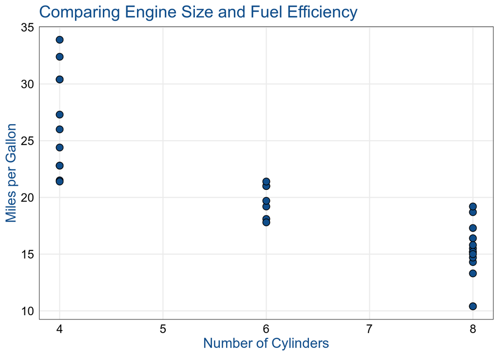

```r
ggplot(mtcars, aes(cyl, mpg)) +
  geom_point(size = 3, pch = 21, fill = "dodgerblue4", colour = "black") +
  labs(x = "Number of Cylinders",
       y = "Miles per Gallon",
       title = "Comparing Engine Size and Fuel Efficiency") +
  theme_bw() +
  theme(axis.ticks = element_blank(),
        axis.text = element_text(size = 12, colour = "black"),
        title = element_text(size = 14, colour = "dodgerblue4"),
        panel.grid.minor = element_blank())
```

Now our plot looks a lot nicer!

Another alternative to making a bunch of little changes ourselves is to use another package, `cowplot`. This package comes with suite of functions, but let’s start with `theme_cowplot()`, which makes a variety of changes to the default look of ggplot2 graphics.

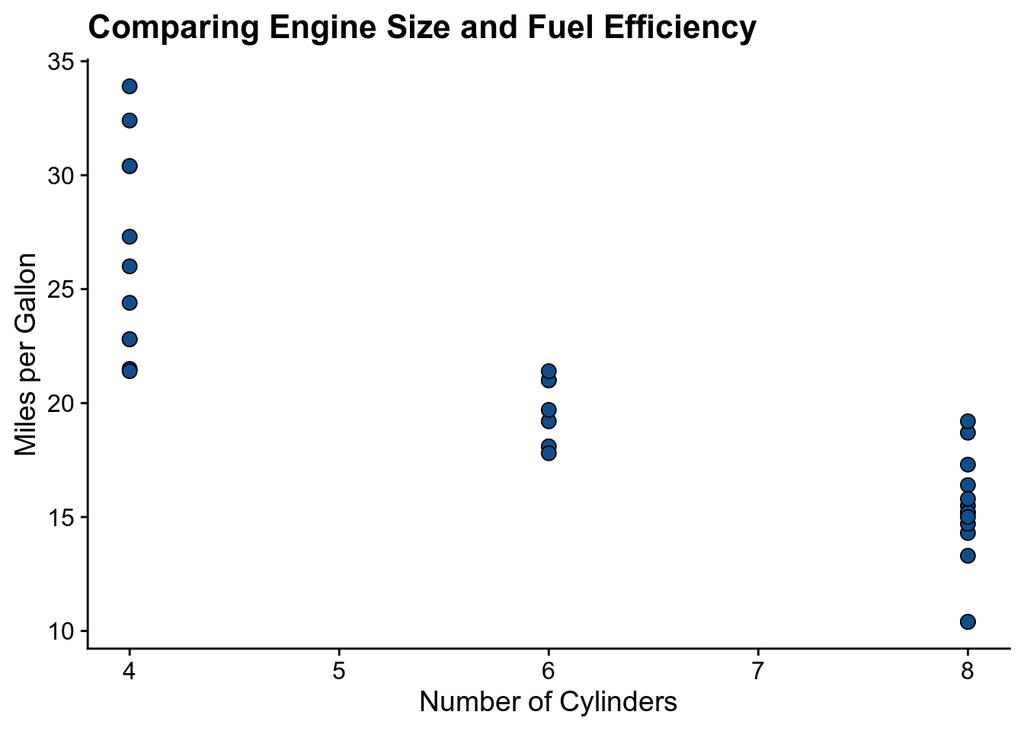

```r
ggplot(mtcars, aes(cyl, mpg)) +
  geom_point(size = 3, pch = 21, fill = "dodgerblue4", colour = "black") +
  labs(x = "Number of Cylinders",
       y = "Miles per Gallon",
       title = "Comparing Engine Size and Fuel Efficiency") +
  theme_cowplot()
```

Another really useful feature of the `cowplot` package is the ability to combine multiple plots into a multi-panel style figure using the `plot_grid()` function. Let’s test it out with an example.

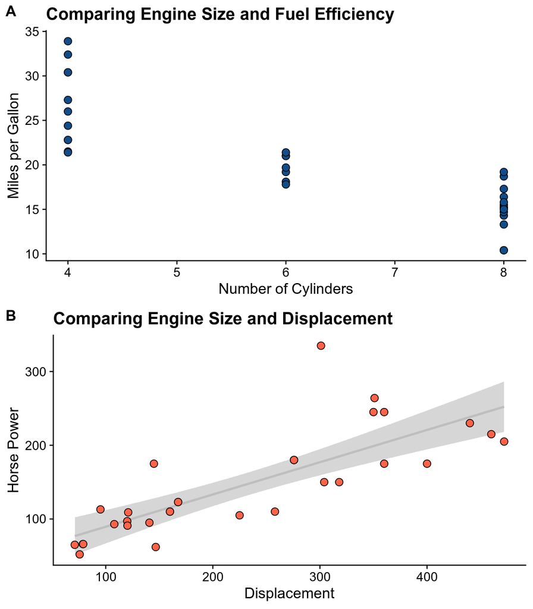

```r
mpgCyl_plot <- ggplot(mtcars, aes(cyl, mpg)) +
  geom_point(size = 3, pch = 21, fill = "dodgerblue4", colour = "black") +
  labs(x = "Number of Cylinders",
       y = "Miles per Gallon",
       title = "Comparing Engine Size and Fuel Efficiency") +
  theme_cowplot()

dispHP_plot <- ggplot(mtcars, aes(disp, hp)) +
  geom_smooth(method = "lm", colour = "grey") +
  geom_point(size = 3, pch = 21, fill = "tomato", colour = "black") +
  labs(x = "Displacement",
       y = "Horse Power",
       title = "Comparing Engine Size and Displacement") +
  theme_cowplot()

plot_grid(mpgCyl_plot, dispHP_plot, nrow = 2, ncol = 1, align = "h", labels = "AUTO")
```

Now let’s move on to another plotting library, `plotly`. Unlike ggplot2, this package allows us to make interactive HTML plots. Let’s see what this looks like with an example. Note the syntax is a bit different then ggplot2, so pay close attention to how we set up our plot.

```r
plot_ly(mtcars, x = ~cyl, y = ~mpg, type = "scatter", text = ~car) %>%
  plotly::layout(
        title = "Comparing Engine Size and Fuel Efficiency",
        xaxis = list(title = "Number of Cylinders"),
        yaxis = list(title = "Miles per Gallons")
    )
```

[interactive chart not shown]

As you can see, hovering our cursor over the points displays the coordinates as well as the name of the vehicle.  
Let’s see how we can tweak this some more.

```r
fit <- lm(mpg ~ cyl, data = mtcars)

plot_ly(
  mtcars, x = ~cyl, y = ~mpg, type = "scatter", text = ~car
) %>%
  add_lines(x = ~cyl, y = fitted(fit), line = list(color = "black")) %>%
  plotly::layout(
    title = "Comparing Engine Size and Fuel Efficiency",
    xaxis = list(title = "Number of Cylinders"),
    yaxis = list(title = "Miles per Gallons")
  )
```

[interactive chart not shown]

We can also extensively format the hover text displayed on the plot, using a bit of HTML language.

```r
fit <- lm(mpg ~ cyl, data = mtcars)

plot_ly(
  mtcars,
  x = ~cyl
) %>%
  add_trace(y = ~mpg,
            mode = "markers",
            marker = list(size = 10),
            hoverinfo = "text",
            text = ~paste0("<b>Car: </b>", car)) %>%
  add_trace(y = fitted(fit), mode = "lines") %>%
  plotly::layout(
    title = "Comparing Engine Size and Fuel Efficiency",
    xaxis = list(title = "Number of Cylinders"),
    yaxis = list(title = "Miles per Gallons")
  )
```

[interactive chart not shown]

Making a boxplot using plotly, specifying custom colours, and adding lines along the x and y axis.

```r
plot_ly(
  mtcars,
  x = ~cyl
) %>%
  add_boxplot(
    y = ~mpg,
    marker = list(color = "black"),
    line = list(color = "black"),
    fillcolor = "white"
  ) %>%
  plotly::layout(
    title = "Comparing Engine Size and Fuel Efficiency",
    xaxis = list(showline = TRUE,
                 title = "Number of Cylinders",
                 titlefont = list(size = 14),
                 tickfont = list(size = 14)),
    yaxis = list(showline = TRUE,
                 title = "Miles per Gallons",
                 titlefont = list(size = 14),
                 tickfont = list(size = 14))
  )
```

[interactive chart not shown]